# A (very) brief introduction to survey experiments

Survey Methodology II

Author

Marga Torre

## 1 Introduction: Why Are Surveys Limited for Studying Causality?

## 2 Introduction: Why Are Surveys Limited for Studying Causality?

Surveys are one of the most common tools in the social sciences. They allow researchers to collect information about people’s opinions, attitudes, behaviors, and characteristics. With surveys, we can:

- Describe social phenomena
- Compare different groups
- Measure how common something is
- Analyze relationships between variables

However, traditional surveys have an important limitation: **they usually allow us to study correlations, but not causes**.

When we analyze survey data, we often find associations between variables. For example:

- People with higher education levels participate more in politics.
- Unemployed individuals report lower levels of well-being.
- Women show greater support for certain social policies.
- People who consume more crime-related news express more negative attitudes toward immigration.

These findings show that variables are related, but they do not tell us whether one variable actually causes the other.

The main problem is that, in regular surveys, we do not control exposure to different conditions. People are not randomly assigned to education levels, unemployment, or media content. Many factors are connected in real life, and there may be other hidden variables influencing the relationship.

For example, if we find that individuals who watch more news about crime are more opposed to immigration, we cannot be sure why. Does exposure to crime news increase anti-immigrant attitudes? Or are people who already hold negative views more likely to choose that type of content? Or is there a third factor — such as political ideology or economic insecurity — affecting both?

Traditional surveys make it difficult to isolate the **causal mechanisms** behind sensitive social and political opinions.

To understand causes more clearly, we need research designs that allow us to control or manipulate key variables. This is where experiments — and especially survey experiments — become important.

## 3 Survey experiments

An experiment is a research method in which variables are manipulated to observe their effects on outcomes. In a typical experiment, we examine the effect of a particular factor by comparing two groups that are **randomly assigned**: Group A, which is exposed to the stimulus (**experimental group**), and Group B, which does not receive the stimulus (**control group**).

The control group, sometimes called the comparison group, is treated in the same way as the experimental group, except that it does not receive the treatment. This is important because it helps us rule out other possible explanations for the results. If both groups are treated equally, any difference between them can be attributed to the treatment itself.

We measure participants on the variable of interest before and after the treatment. By comparing these measurements, we can see whether the treatment caused a change. This helps us determine if there is a true cause-and-effect relationship between the variables.

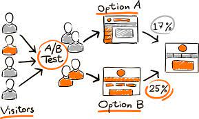

**Survey experiments** are experiments conducted within surveys. The widespread adoption of online surveys has made it easier to implement certain types of experiments by streamlining both participant randomization and variable manipulation.

There are several ways to design experiments:

- Factorial designs
- Correspondence analysis
- Image and video manipulations
- Task or exercise experiments
- Conjoint experiments
- Quasi-experiments
- …

## 4 Popular types of survey experiments

### 4.1 Factorial Survey Analysis (FSA) (vignette analysis)

Factorial Survey Analysis (FSA) is a method that presents respondents with fictional situations (*vignettes*) and asks them to evaluate or rate them. In survey research, a vignette works like a short written story. It describes hypothetical people, objects, or situations, and the researcher carefully controls how the story is constructed.

The key feature of FSA is that the characteristics within the vignette are systematically varied. Each vignette is built from several **dimensions** (for example: gender, age, occupation, nationality), and each dimension has different **levels** (e.g., male/female, high/low income, employed/unemployed). These elements are combined to create multiple possible versions of the same basic story.

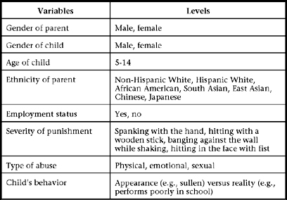

Example of variables and levels in vignettes desing

These are combined to design the vignettes

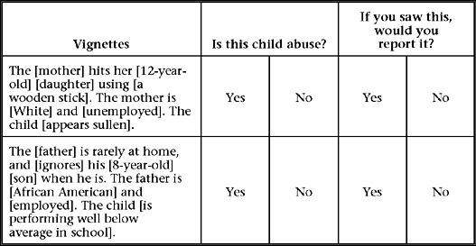

Examples of vignettes

Importantly, each respondent receives a different **random version of the vignette**. Because the characteristics are randomly assigned, they are independent from each other. This allows researchers to identify the separate effect of each characteristic on respondents’ evaluations.

In short, FSA combines the strengths of surveys (large samples, external validity) with the logic of experiments (randomization and causal identification), making it a powerful tool for studying attitudes, norms, and decision-making processes — especially on sensitive topics.

By using fictional stories, factorial survey analysis collects information about people’s opinions or attitudes without asking direct questions. For this reason, a vignette design is especially useful for exploring sensitive topics that respondents might feel uncomfortable discussing openly. For example:

- Would you consider hiring a pregnant woman for a position at your company?
- Would you feel uneasy if a person from group X lived next door?

In a typical survey, few people would openly admit to holding discriminatory attitudes. However, when these questions are embedded in a fictional scenario, respondents are more likely to express their true opinions. That said, if social desirability bias is not a major concern, vignettes may not provide much more insight than direct questions.

In conclusion, vignette studies have two main advantages:

- They combine characteristics in a random way, which helps researchers study the effect of each variable separately.
- They reduce social desirability bias, because participants do not know which specific characteristic is being studied, and therefore are less likely to adjust their answers.

### 4.2 Video manipulation

Video manipulation can also be utilized experimentally. For instance, in [this paper by Hernandez and Panico](https://journals.sagepub.com/doi/10.1177/1465116520935198), the authors examine the effects of EU institutional advertising on public support for European integration. In their panel survey experiment, they compare different types of advertisements to assess their impact on individual opinions:

- [Policy benefits treatment](https://multimedia.europarl.europa.eu/en/what-%20do-i-get-from-the-eu_B01-ESN-171115_ev)
- [Economic costs treatment](https://multimedia.europarl.europa.eu/en/how-%20much-does-the-eu-cost-me_B01-ESN-171122_ev)

The findings indicate that advertisements can increase support for the EU, and that ads emphasizing the policy benefits of European integration are more effective than those highlighting its cost reductions. This experimental approach, which uses video manipulation, helps researchers identify which types of messages are more persuasive. It also allows them to test causal effects in a controlled setting, improving our understanding of how political communication shapes public attitudes. More broadly, this method can be used to design more effective information campaigns and to study how different frames or narratives influence citizens’ opinions about political issues.

### 4.3 Conjoint analysis

Conjoint analysis, often used in market research, is designed to understand **how customers value different features of products or services**. This technique is based on the idea that any product can be divided into attributes, which collectively influence users’ perceived value.

Four key parts of a conjoint analysis survey include:

- Question: Sets the scene for the respondent about the product choice they are pretending to make.
- Attributes: Features of a product that matter to customers when they decide to buy.
- Profiles: Different sets of attribute values that come together to describe a product.
- Levels: The different possible values for each attribute

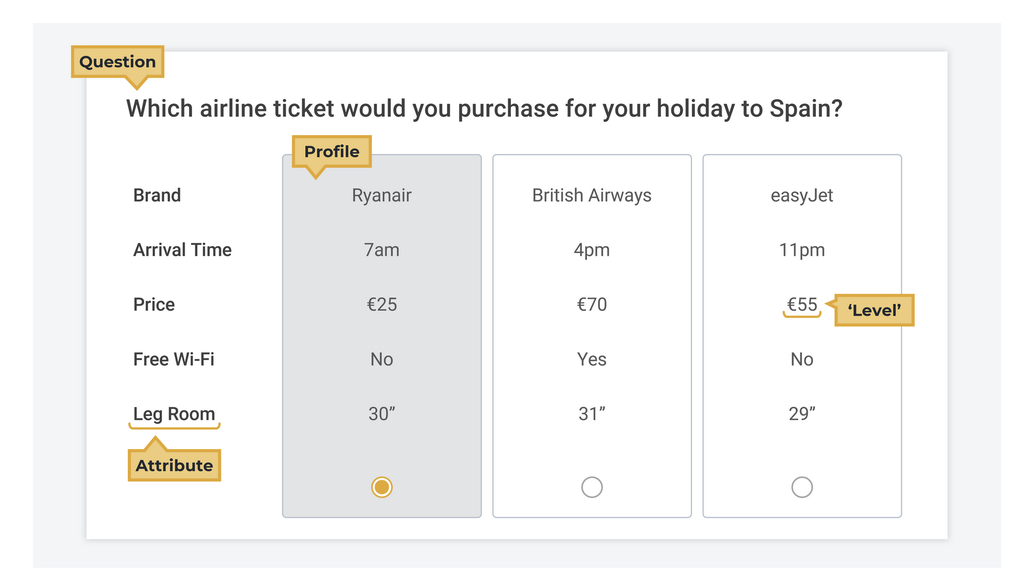

Example of conjoint desing

Conjoint analysis is typically conducted through a specialized survey that asks respondents to rate a set of alternatives, each with randomly varied attributes. It assesses how much people like different characteristics (like price, brand, or features) when they are looking at products. The results of a conjoint survey give information on **how important each characteristic is compared to the others** (for example, how price compares to brand).

In recent times, conjoint analysis has been generalized in social science. [This LinkedIn post](https://www.linkedin.com/pulse/role-conjoint-analysis-political-decision-making-datailorinc/?trk=public_post_main-feed-card_feed-article-content) provides a summary of common applications of conjoint analysis in political decision-making.

For example, [Clavería and Lavezzolo (2023)](https://journals.sagepub.com/doi/10.1177/01925121231214272) examine how citizens evaluate the personal and political traits of government ministers. Using conjoint analysis, they analyze whether women are judged differently than men when serving as finance minister (FM), a position traditionally viewed as more “masculine.” To do so, they randomly vary gender along with other attributes, such as education, origin, and political experience. This approach makes it possible to test how gender stereotypes shape evaluations in one of the most male-dominated areas of government.

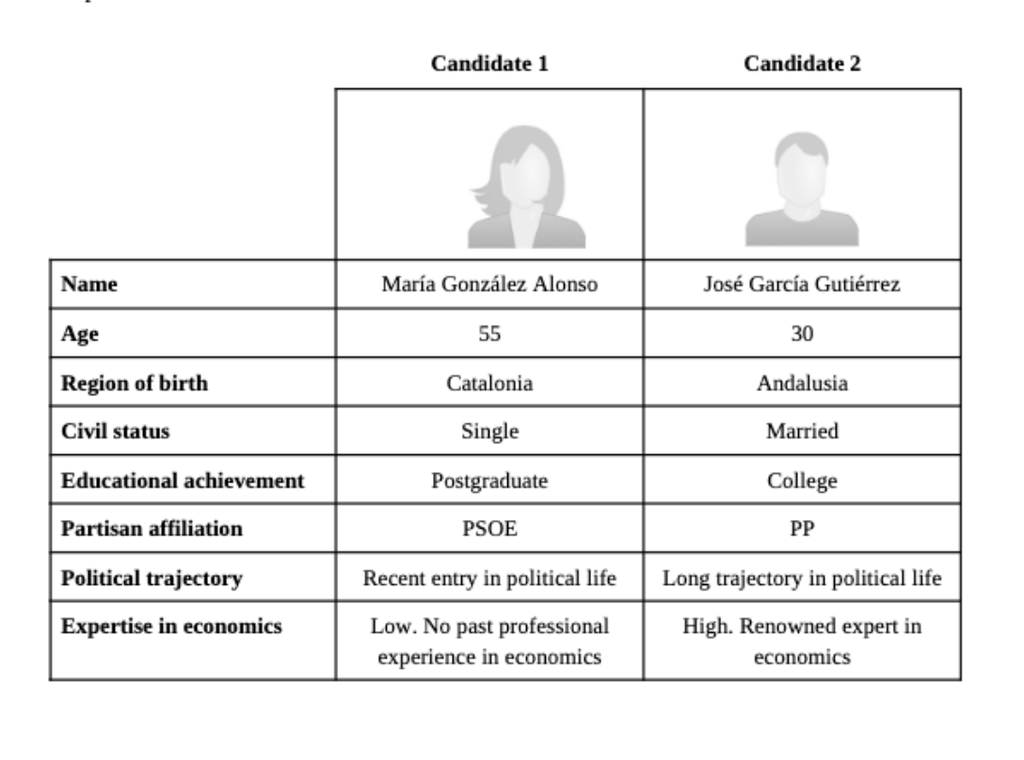

Example of how candidate profiles are displayed to subjects during the experiment

If interested in knowing more about conjoint analysis, here are other relevant examples of use in the Social Sciences:

- Causal Inference in Conjoint Analysis: Understanding Multidimensional Choices via Stated Preference Experiments, by Heinmueller et al. 2017
- [Conjoint Survey Experiments](https://cpb-us-w2.wpmucdn.com/web.sas.upenn.edu/dist/f/49/files/2019/09/handbook-draft-07-09202019-1.pdf), by Bansak et al, 2019
- [Measuring Subgroup Preferences in Conjoint Experiments](https://www.cambridge.org/core/journals/political-analysis/article/abs/measuring-subgroup-preferences-in-conjoint-experiments/4F2C21AC02753F1FFF2F5EA0F943C1B2), by Leeper et al., 2019

### 4.4 Natural experiments

Natural experiments are studies where the process isn’t randomized like in traditional experiments. Instead, they use external events or situations, such as policy changes, natural disasters, or economic shifts, to group subjects in a way that’s similar to random assignment. The key advantage of natural experiments is that they allow for understanding cause and effect in situations where controlled experiments aren’t possible or ethical. However, they can be complicated because researchers have less control over grouping and other influencing factors. Despite these issues, natural experiments can offer important insights into how things work in real life.

[In this paper](https://journals.sagepub.com/doi/epub/10.1177/2053168017714185), Macarena Ares and Enrique Hernández study how corruption scandals affect citizens’ trust in politicians.

- They focus on a real corruption case in Spain: [the Bárcenas scandal](https://en.wikipedia.org/wiki/B%C3%A1rcenas_affair).
- The scandal became public during the fieldwork of the European Social Survey (ESS).
- Because interview timing was almost random, some respondents were interviewed **before** the scandal was revealed and others **after**.

Why is this important?

- This situation creates a **natural experiment**.
- It allows the authors to compare levels of political trust before and after exposure to the scandal.
- Therefore, they can directly estimate the causal effect of corruption on political trust.

Similarly, [in this paper](https://journals.sagepub.com/doi/10.1177/23780231241276343), Sander Wagner and Ivaylo Petev examine discrimination on Airbnb after the terrorist attacks in Paris in November 2015.

- They use detailed panel data on Airbnb listings and transactions in Paris.
- The timing of the attacks creates a quasi-experimental setting, allowing comparison before and after the event.
- They find that discrimination against Arab and Muslim hosts increased significantly after the attacks.
- These hosts experienced lower occupancy rates and lower revenues compared to the period before the attacks.

Using a natural experiment approach, the study shows how external political events can intensify discrimination and produce real economic consequences for minority groups in online markets.

## 5 Panel Research Companies

A survey panel company, or panel provider, is a company/business that builds a large group of people, called panelists, who are ready to take part in surveys and other market research for rewards (e.g. gift cards). Panelists provide personal details like their age, gender, location, and income when they sign up. This information helps the company select the right people for different surveys, based on their backgrounds and sometimes more detailed information.

Online survey panels are commonly used by companies, market research agencies, scholars, and government bodies to collect information and opinions on products, services, or social matters. Panel providers offer their clients access to a large and diverse pool of respondents, allow researchers to target specific groups, and manage the survey process efficiently from distribution to data collection.

Some popular panel companies:

- [Cint](https://www.cint.com/)
- [Kantar](https://www.kantar.com/campaigns/pf/Quality-Panel-and-First-Party-Data-Sources?utm_campaign=2023%20Quality%20Data&utm_source=quirks&utm_medium=Top%20Research%20Panels%202023)
- [Symmetric](https://www.symmetricsampling.com/panels/)
- [Netquest](https://www.netquest.com/es/panel)

Despite these advantages, online panels face increasing challenges.

- Survey professionalism: Some respondents participate in many surveys mainly for financial incentives. This phenomenon, known as **survey professionalism**, can affect data quality. Professional respondents may learn how surveys work and adjust their answers strategically. See: [Survey Professionalism: New Evidence from Web Browsing Data](https://www.cambridge.org/core/journals/political-analysis/article/survey-professionalism-new-evidence-from-web-browsing-data/552625B9C6C5F32BA1DD69435043C184)
- Bots and fraudulent responses: Another growing problem is the presence of bots or automated programs that enter panels and complete surveys to collect rewards. These fake respondents can seriously distort results. Panels use specific methods to reduce this problem, as for example:
  - CAPTCHA verification
  - Attention-check questions
  - Speeding checks (excluding respondents who answer too fast)
  - Consistency checks across answers
  - IP address and device fingerprint monitoring
  - Screening questions designed to detect unrealistic profiles

As online research becomes more common, ensuring data quality has become a central concern for researchers using survey panels.